[← Back to All Parables](https://www.kameronyork.com/parables/)

# The Tares

by Kameron York

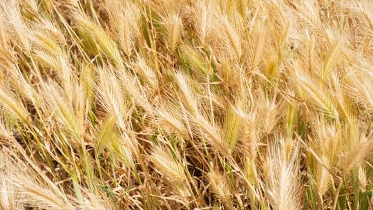

#### Reference:

[Matthew 13:24-30](https://www.churchofjesuschrist.org/study/scriptures/nt/matt/13?lang=eng&id=24-30#p24)

#### What are Tares? How are they different from Wheat?

Tares, according the the Bible Dictionary, are known as, “…darnel grass, a poisonous weed, which, until it comes into ear, is similar in appearance to wheat” (Bible Dictionary, “[Tares](https://www.churchofjesuschrist.org/study/scriptures/bd/tares.p1?lang=eng#p1)”). The WikiPedia article adds on to this definition, saying, “The similarity between these two plants is so great that in some regions, darnel is referred to as”false wheat” (WikiPedia, “[Lolium Temulentum](https://en.wikipedia.org/wiki/Lolium_temulentum#cite_ref-2)”). Darnel grass has poisonous properties that reportedly cause cause a drunken nausea after eating the plant. In fact “Temulentum” - the second half of the Latin name - means “Drunk” in Latin.

#### What Happens in the Narrative of the Parable of the Tares?

The Parable of the Tares is a story about a householder and his servants. A householder sowed **good** seeds in his field. At night, while he and his servants slept, an enemy entered the field of good seeds and sowed tares. An unspecified amount of time later, the tares were discovered in the field. As noted in the previous section, tares appear identical to wheat until the wheat springs forth it’s corn. Therefore, it can be interpreted that enough time has passed for the wheat to be matured.  
Seeing the tares in the field the servants go to the householder and ask if he had planted bad seeds. The householder knows this is the work of an enemy. Seeking a solution to the problem, the servants and ask if they should pull up the tares from the field. The householder says, “Nay; lest while ye gather up the tares, ye root up also the wheat with them. Let both grow together until the harvest: and in the time of harvest I will say to the reapers, Gather ye together first the tares, and bind them in bundles to burn them: but gather the wheat into my barn.”  
The narrative of this parable teaches two important lessons: 1. Good seeds come from the householder and bad seeds come from the enemy. 2. Good plants will be gathered into the barn during the harvest, while bad plants will be burned.

#### What Does the Parable of the Tares Mean?

Like the parable of the Sower, the Savior explains the meaning of this parable. The explanation can be found in [Matthew 13:36-43](https://www.churchofjesuschrist.org/study/scriptures/nt/matt/13?lang=eng&id=36-43#p36). The Lord teaches us the meaning of the symbols in the parable:  
**The Sower** represents Jesus.  
**The Seed** represents the followers of Christ.  
**The Field** represents the world.  
**The Tares** represents the followers of the Devil.  
**The Enemy** represents the Devil.  
**The Harvest** represents the Second Coming of Christ.  
**The Reapers** represents angels.  
**The Fire** represents being cast out of God’s presence.  
**The Barn** represents the presence of God.  
With these symbols in mind, the meaning of the parable is clear. This is a story about our time on Earth, the Second Coming, and the Final Judgement. Christ teaches that both good and bad are allowed to exist in the world because rooting out the bad will be harmful to the good as well. The Book of Mormon teaches this principle clearly in [Alma 14:10-11](https://www.churchofjesuschrist.org/study/scriptures/bofm/alma/14?lang=eng&id=10-11#p11) where Alma says God allows bad things to happen to good people, “…that the judgments which he shall exercise upon them in his wrath may be just.” A criminal cannot be punished for a crime they simply thought about. Only actions can cause punishments. In the same vein only actions can cause rewards. If our time here on Earth is meant as a test, then the people here must be allowed to do things whether they are good or bad. That is why the Householder allows the Tares to grow alongside the Wheat.  
The parable also teaches us about the second coming of the Savior and the Final Judgement. In the parable the wheat is separated from the tares each receiving a different outcome. This idea of separating the good from the bad during the second coming is not exclusive to this parable. In fact, here is a list of passages that teach the same:  
[Matthew 25:31-64](https://www.churchofjesuschrist.org/study/scriptures/nt/matt/25?lang=eng&id=31-46#p31) - The parable of the Sheep and the Goats.  
[Revelation 20:11-15](https://www.churchofjesuschrist.org/study/scriptures/nt/rev/20?lang=eng&id=11-15#p11) - “whosoever was not found written in the book of life was cast into the lake of fire.”  
[Luke 17:34-36](https://www.churchofjesuschrist.org/study/scriptures/nt/Luke/17?lang=eng&id=34-36#p34) - “Two men shall be in the field; the one shall be taken, and the other left.”  
[3 Nephi 26:5-6](https://www.churchofjesuschrist.org/study/scriptures/bofm/3-ne/26?lang=eng&id=5-6#p5) - “If they be good, to the resurrection of everlasting life; and if they be evil, to the resurrection of damnation.”  
[Alma 5:57-58](https://www.churchofjesuschrist.org/study/scriptures/bofm/alma/5?lang=eng&id=57-58#p57) - “The names of the wicked shall not be mingled with the names of my people; For the names of the righteous shall be written in the book of life, and unto them will I grant an inheritance at my right hand.”  
[Alma 40:25-26](https://www.churchofjesuschrist.org/study/scriptures/bofm/alma/40?lang=eng&id=25-26#p25) - “And then shall the righteous shine forth in the kingdom of God… But behold, an awful death cometh upon the wicked… but they are cast out, and consigned to partake of the fruits of their labors or their works, which have been evil.”  
Put simply the parable teaches that, in the end, good things will come to good people, and bad things will come to bad people. This is the antithesis of what the parable is teaching about our lives on Earth. Often bad things happen to good people in mortality, but the Savior is teaching us that this is not the order of heaven. In heaven good things will not come to someone who has done bad things.

#### How Can We be like the Wheat in the Parable?

[output not shown]